# Comunicate Data Findings

Ford GoBike is a bike-sharing system covering the greater San Francisco Bay area. Using Python data science and data visualization libraries this documents will explore the data from individual rides in hopes of understanding the data’s structure, oddities, patterns and relationships within the dataset

## Preliminary Wrangling

### 1. Data gathering

```python
# import pacakeges and libraries
import pandas as pd
import numpy as np
import datetime as dt
import matplotlib.pyplot as plt
import seaborn as sns

%matplotlib inline
```

```python
# read in CSV file
df = pd.read_csv('201902-fordgobike-tripdata.csv')
```

### 2. Assessing Data

```python
# Overview of the data set
print(df.shape)
print(df.info())
df.head()
```

```
(183412, 16)
<class 'pandas.core.frame.DataFrame'>
RangeIndex: 183412 entries, 0 to 183411
Data columns (total 16 columns):
 #   Column                   Non-Null Count   Dtype
---  ------                   --------------   -----
 0   duration_sec             183412 non-null  int64
 1   start_time               183412 non-null  object
 2   end_time                 183412 non-null  object
 3   start_station_id         183215 non-null  float64
 4   start_station_name       183215 non-null  object
 5   start_station_latitude   183412 non-null  float64
 6   start_station_longitude  183412 non-null  float64
 7   end_station_id           183215 non-null  float64
 8   end_station_name         183215 non-null  object
 9   end_station_latitude     183412 non-null  float64
 10  end_station_longitude    183412 non-null  float64
 11  bike_id                  183412 non-null  int64
 12  user_type                183412 non-null  object
 13  member_birth_year        175147 non-null  float64
 14  member_gender            175147 non-null  object
 15  bike_share_for_all_trip  183412 non-null  object
dtypes: float64(7), int64(2), object(7)
memory usage: 22.4+ MB
None
```

|  | duration_sec | start_time | end_time | start_station_id | start_station_name | start_station_latitude | start_station_longitude | end_station_id | end_station_name | end_station_latitude | end_station_longitude | bike_id | user_type | member_birth_year | member_gender | bike_share_for_all_trip |
| --- | --- | --- | --- | --- | --- | --- | --- | --- | --- | --- | --- | --- | --- | --- | --- | --- |
| 0 | 52185 | 2019-02-28 17:32:10.1450 | 2019-03-01 08:01:55.9750 | 21.0 | Montgomery St BART Station (Market St at 2nd St) | 37.789625 | -122.400811 | 13.0 | Commercial St at Montgomery St | 37.794231 | -122.402923 | 4902 | Customer | 1984.0 | Male | No |
| 1 | 42521 | 2019-02-28 18:53:21.7890 | 2019-03-01 06:42:03.0560 | 23.0 | The Embarcadero at Steuart St | 37.791464 | -122.391034 | 81.0 | Berry St at 4th St | 37.775880 | -122.393170 | 2535 | Customer | NaN | NaN | No |
| 2 | 61854 | 2019-02-28 12:13:13.2180 | 2019-03-01 05:24:08.1460 | 86.0 | Market St at Dolores St | 37.769305 | -122.426826 | 3.0 | Powell St BART Station (Market St at 4th St) | 37.786375 | -122.404904 | 5905 | Customer | 1972.0 | Male | No |
| 3 | 36490 | 2019-02-28 17:54:26.0100 | 2019-03-01 04:02:36.8420 | 375.0 | Grove St at Masonic Ave | 37.774836 | -122.446546 | 70.0 | Central Ave at Fell St | 37.773311 | -122.444293 | 6638 | Subscriber | 1989.0 | Other | No |
| 4 | 1585 | 2019-02-28 23:54:18.5490 | 2019-03-01 00:20:44.0740 | 7.0 | Frank H Ogawa Plaza | 37.804562 | -122.271738 | 222.0 | 10th Ave at E 15th St | 37.792714 | -122.248780 | 4898 | Subscriber | 1974.0 | Male | Yes |

```python
df.start_time.unique()
```

```
array(['2019-02-28 17:32:10.1450', '2019-02-28 18:53:21.7890',
       '2019-02-28 12:13:13.2180', ..., '2019-02-01 00:06:05.5490',
       '2019-02-01 00:05:34.3600', '2019-02-01 00:00:20.6360'],
      dtype=object)
```

From the above, we can idenify that there are some data tidynss and quality issues within our dataset.

### Data issues:

1. Missing data in the membership info, start and end trip locations
2. start_time saved as a string instead of datetime data type
3. end_time saved as a string instead of datetime data type
4. user_type is saved as a string and can be changed to categorical data type
5. member_birth_year is saved as a float and can be changed to an int
6. member_gender is saved as a string and can be changed to categorical data type
7. bike_share_for_all_trip is saved as a string and can be changed to categorical data type

### 3. Data cleaning

```python
df_copy = df
df_copy.info()
```

```
<class 'pandas.core.frame.DataFrame'>
RangeIndex: 183412 entries, 0 to 183411
Data columns (total 16 columns):
 #   Column                   Non-Null Count   Dtype
---  ------                   --------------   -----
 0   duration_sec             183412 non-null  int64
 1   start_time               183412 non-null  object
 2   end_time                 183412 non-null  object
 3   start_station_id         183215 non-null  float64
 4   start_station_name       183215 non-null  object
 5   start_station_latitude   183412 non-null  float64
 6   start_station_longitude  183412 non-null  float64
 7   end_station_id           183215 non-null  float64
 8   end_station_name         183215 non-null  object
 9   end_station_latitude     183412 non-null  float64
 10  end_station_longitude    183412 non-null  float64
 11  bike_id                  183412 non-null  int64
 12  user_type                183412 non-null  object
 13  member_birth_year        175147 non-null  float64
 14  member_gender            175147 non-null  object
 15  bike_share_for_all_trip  183412 non-null  object
dtypes: float64(7), int64(2), object(7)
memory usage: 22.4+ MB
```

**Issue**: Missing data in the membership info, start and end trip locations

**Define**: Use the pandas dropna() function to drop rows with missing data.

```python
df_copy.dropna(inplace=True)
```

**Test**:

```python
df_copy.info()
```

```
<class 'pandas.core.frame.DataFrame'>
Int64Index: 174952 entries, 0 to 183411
Data columns (total 16 columns):
 #   Column                   Non-Null Count   Dtype
---  ------                   --------------   -----
 0   duration_sec             174952 non-null  int64
 1   start_time               174952 non-null  object
 2   end_time                 174952 non-null  object
 3   start_station_id         174952 non-null  float64
 4   start_station_name       174952 non-null  object
 5   start_station_latitude   174952 non-null  float64
 6   start_station_longitude  174952 non-null  float64
 7   end_station_id           174952 non-null  float64
 8   end_station_name         174952 non-null  object
 9   end_station_latitude     174952 non-null  float64
 10  end_station_longitude    174952 non-null  float64
 11  bike_id                  174952 non-null  int64
 12  user_type                174952 non-null  object
 13  member_birth_year        174952 non-null  float64
 14  member_gender            174952 non-null  object
 15  bike_share_for_all_trip  174952 non-null  object
dtypes: float64(7), int64(2), object(7)
memory usage: 22.7+ MB
```

**Issue**: start_time saved as a string instead of datetime data type

**Define**: Use the pandas to_datetime() function to convert the start_time column into a datetime object

```python
df_copy['start_time'] = pd.to_datetime(df['start_time'])
```

**Test**:

```python
df_copy.dtypes
```

```
duration_sec                        int64
start_time                 datetime64[ns]
end_time                           object
start_station_id                  float64
start_station_name                 object
start_station_latitude            float64
start_station_longitude           float64
end_station_id                    float64
end_station_name                   object
end_station_latitude              float64
end_station_longitude             float64
bike_id                             int64
user_type                          object
member_birth_year                 float64
member_gender                      object
bike_share_for_all_trip            object
dtype: object
```

**Issue**: end_time saved as a string instead of datetime data type

**Define**: Use the pandas to_datetime() function to convert the end_time column into a datetime object

```python
df_copy['end_time'] = pd.to_datetime(df['end_time'])
```

**Test**:

```python
df_copy.dtypes
```

```
duration_sec                        int64
start_time                 datetime64[ns]
end_time                   datetime64[ns]
start_station_id                  float64
start_station_name                 object
start_station_latitude            float64
start_station_longitude           float64
end_station_id                    float64
end_station_name                   object
end_station_latitude              float64
end_station_longitude             float64
bike_id                             int64
user_type                          object
member_birth_year                 float64
member_gender                      object
bike_share_for_all_trip            object
dtype: object
```

**Issue**: user_type is saved as a string and can be changed to categorical data type

**Define**: use the pandas astype() function to convert the data type from a string to categorical data

```python
df_copy['user_type'] = df['user_type'].astype('category')
```

**Test**:

```python
df_copy.dtypes
```

```
duration_sec                        int64
start_time                 datetime64[ns]
end_time                   datetime64[ns]
start_station_id                  float64
start_station_name                 object
start_station_latitude            float64
start_station_longitude           float64
end_station_id                    float64
end_station_name                   object
end_station_latitude              float64
end_station_longitude             float64
bike_id                             int64
user_type                        category
member_birth_year                 float64
member_gender                      object
bike_share_for_all_trip            object
dtype: object
```

**Issue**: member_birth_year is saved as a float and can be changed to an int

**Define**: use the pythons int() function to convert the data type from a float to an int

```python
df_copy['member_birth_year'] = df['member_birth_year'].astype('int')
```

**Test**:

```python
df_copy.dtypes
```

```
duration_sec                        int64
start_time                 datetime64[ns]
end_time                   datetime64[ns]
start_station_id                  float64
start_station_name                 object
start_station_latitude            float64
start_station_longitude           float64
end_station_id                    float64
end_station_name                   object
end_station_latitude              float64
end_station_longitude             float64
bike_id                             int64
user_type                        category
member_birth_year                   int32
member_gender                      object
bike_share_for_all_trip            object
dtype: object
```

**Issue**: member_gender is saved as a string and can be changed to categorical data type

**Define**: use the pandas astype() function to convert the data type from a string to categorical data

```python
df_copy['member_gender'] = df['member_gender'].astype('category')
```

**Test**:

```python
df_copy.dtypes
```

```
duration_sec                        int64
start_time                 datetime64[ns]
end_time                   datetime64[ns]
start_station_id                  float64
start_station_name                 object
start_station_latitude            float64
start_station_longitude           float64
end_station_id                    float64
end_station_name                   object
end_station_latitude              float64
end_station_longitude             float64
bike_id                             int64
user_type                        category
member_birth_year                   int32
member_gender                    category
bike_share_for_all_trip            object
dtype: object
```

**Issue**: bike_share_for_all_trip is saved as a string and can be changed to categorical data type

**Define**: use the pandas astype() function to convert the data type from a string to categorical data

```python
df_copy['bike_share_for_all_trip'] = df['bike_share_for_all_trip'].astype('category')
```

**Test**:

```python
df_copy.dtypes
```

```
duration_sec                        int64
start_time                 datetime64[ns]
end_time                   datetime64[ns]
start_station_id                  float64
start_station_name                 object
start_station_latitude            float64
start_station_longitude           float64
end_station_id                    float64
end_station_name                   object
end_station_latitude              float64
end_station_longitude             float64
bike_id                             int64
user_type                        category
member_birth_year                   int32
member_gender                    category
bike_share_for_all_trip          category
dtype: object
```

For simplicity, let's also convert duration from seconds to minutes.

```python
# converting duration from seconds to minutes
df_copy['duration_min'] = df['duration_sec']/60
df_copy.info()
```

```
<class 'pandas.core.frame.DataFrame'>
Int64Index: 174952 entries, 0 to 183411
Data columns (total 17 columns):
 #   Column                   Non-Null Count   Dtype
---  ------                   --------------   -----
 0   duration_sec             174952 non-null  int64
 1   start_time               174952 non-null  datetime64[ns]
 2   end_time                 174952 non-null  datetime64[ns]
 3   start_station_id         174952 non-null  float64
 4   start_station_name       174952 non-null  object
 5   start_station_latitude   174952 non-null  float64
 6   start_station_longitude  174952 non-null  float64
 7   end_station_id           174952 non-null  float64
 8   end_station_name         174952 non-null  object
 9   end_station_latitude     174952 non-null  float64
 10  end_station_longitude    174952 non-null  float64
 11  bike_id                  174952 non-null  int64
 12  user_type                174952 non-null  category
 13  member_birth_year        174952 non-null  int32
 14  member_gender            174952 non-null  category
 15  bike_share_for_all_trip  174952 non-null  category
 16  duration_min             174952 non-null  float64
dtypes: category(3), datetime64[ns](2), float64(7), int32(1), int64(2), object(2)
memory usage: 19.9+ MB
```

**Issue:** Users age can be created from birth year

**Define:** Subtract the members birth year from the year that the data was collected i.e. 2019

```python
df_copy['member_age'] = 2019 - df['member_birth_year']
```

#### Test:

```python
df_copy['member_age'].describe()
```

```
count    174952.000000
mean         34.196865
std          10.118731
min          18.000000
25%          27.000000
50%          32.000000
75%          39.000000
max         141.000000
Name: member_age, dtype: float64
```

Seems that there might be some inaccurate date present in the age as there are users recorded as 140 years old. Let's fix this by the quantile function to remove any age above the 95th percentile.

```python
# removing all entries where age > 95th percentile
df_copy = df[df['member_age'] < df['member_age'].quantile(0.95)]
```

```python
df_copy['member_age'].describe()
```

```
count    165876.000000
mean         32.733777
std           7.969138
min          18.000000
25%          27.000000
50%          31.000000
75%          37.000000
max          54.000000
Name: member_age, dtype: float64
```

### What is the structure of the dataset?

The dataset contains 183412 rides across the month of Feburary 2019 with 16 features which can be categorised into:

1. Date, time and duration of each trip
2. Start locations
3. End locations
4. Bike ID
5. User demographic (Age, Gender, user type, bike sharing)

```python
df_copy.head()
```

|  | duration_sec | start_time | end_time | start_station_id | start_station_name | start_station_latitude | start_station_longitude | end_station_id | end_station_name | end_station_latitude | end_station_longitude | bike_id | user_type | member_birth_year | member_gender | bike_share_for_all_trip | duration_min | member_age |
| --- | --- | --- | --- | --- | --- | --- | --- | --- | --- | --- | --- | --- | --- | --- | --- | --- | --- | --- |
| 0 | 52185 | 2019-02-28 17:32:10.145 | 2019-03-01 08:01:55.975 | 21.0 | Montgomery St BART Station (Market St at 2nd St) | 37.789625 | -122.400811 | 13.0 | Commercial St at Montgomery St | 37.794231 | -122.402923 | 4902 | Customer | 1984 | Male | No | 869.750000 | 35 |
| 2 | 61854 | 2019-02-28 12:13:13.218 | 2019-03-01 05:24:08.146 | 86.0 | Market St at Dolores St | 37.769305 | -122.426826 | 3.0 | Powell St BART Station (Market St at 4th St) | 37.786375 | -122.404904 | 5905 | Customer | 1972 | Male | No | 1030.900000 | 47 |
| 3 | 36490 | 2019-02-28 17:54:26.010 | 2019-03-01 04:02:36.842 | 375.0 | Grove St at Masonic Ave | 37.774836 | -122.446546 | 70.0 | Central Ave at Fell St | 37.773311 | -122.444293 | 6638 | Subscriber | 1989 | Other | No | 608.166667 | 30 |
| 4 | 1585 | 2019-02-28 23:54:18.549 | 2019-03-01 00:20:44.074 | 7.0 | Frank H Ogawa Plaza | 37.804562 | -122.271738 | 222.0 | 10th Ave at E 15th St | 37.792714 | -122.248780 | 4898 | Subscriber | 1974 | Male | Yes | 26.416667 | 45 |
| 6 | 1147 | 2019-02-28 23:55:35.104 | 2019-03-01 00:14:42.588 | 300.0 | Palm St at Willow St | 37.317298 | -121.884995 | 312.0 | San Jose Diridon Station | 37.329732 | -121.901782 | 3803 | Subscriber | 1983 | Female | No | 19.116667 | 36 |

### What is/are the main feature(s) of interest in the dataset?

The main feature that I am interested in exploring is the ride usage of the bikes, captured in the 'duration_sec' variable as well as the number of users at any given point in time.

For ease of reference let's convert the ride duration from seconds to minutes.

```python
# converting duration from seconds to minutes

df_copy['duration_min'] = df['duration_sec']/60
df_copy.info()
```

```
<class 'pandas.core.frame.DataFrame'>
Int64Index: 165876 entries, 0 to 183411
Data columns (total 18 columns):
 #   Column                   Non-Null Count   Dtype
---  ------                   --------------   -----
 0   duration_sec             165876 non-null  int64
 1   start_time               165876 non-null  datetime64[ns]
 2   end_time                 165876 non-null  datetime64[ns]
 3   start_station_id         165876 non-null  float64
 4   start_station_name       165876 non-null  object
 5   start_station_latitude   165876 non-null  float64
 6   start_station_longitude  165876 non-null  float64
 7   end_station_id           165876 non-null  float64
 8   end_station_name         165876 non-null  object
 9   end_station_latitude     165876 non-null  float64
 10  end_station_longitude    165876 non-null  float64
 11  bike_id                  165876 non-null  int64
 12  user_type                165876 non-null  category
 13  member_birth_year        165876 non-null  int32
 14  member_gender            165876 non-null  category
 15  bike_share_for_all_trip  165876 non-null  category
 16  duration_min             165876 non-null  float64
 17  member_age               165876 non-null  int32
dtypes: category(3), datetime64[ns](2), float64(7), int32(2), int64(2), object(2)
memory usage: 19.5+ MB
```

### What features in the dataset do you think will help support your investigation into your feature(s) of interest?

I expect that the users age would have a strong effect on the ride durations, with younger users going for longer ride durations. Other features that I would also expect to influence ride duration, but to a lesser extent, would include user’s membership status, gender and start location.

## 4. Univariate Exploration

First, let's look at the main variable ride duration in the **ride duration** variable.

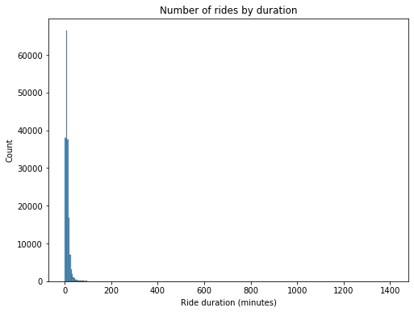

```python
#assignign hte blue colour to be used across our visualisations
blue = sns.color_palette()[0]

# creating a bin size of 5 min
binsize = 5
bins = np.arange(0, df['duration_min'].max()+binsize, binsize)

#plotting a countplot of ride duration
plt.figure(figsize=(8,6))
sns.histplot(data = df, x = 'duration_min', bins=bins, color = blue)

plt.xlabel("Ride duration (minutes)")
plt.ylabel('Count')
plt.title('Number of rides by duration');

# for p in ax.patches:
#        ax.annotate('{}'.format(p.get_height()), (p.get_x()+0.3, p.get_height()+50))
```

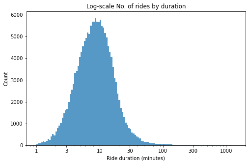

```python
# the ride duration has a long right tailed distribution, lets use a log scale to investigate

# creating the log binsize and tick lables
binsize = 0.025
bins = 10 ** np.arange(0, np.log10(df_copy['duration_min'].max())+binsize, binsize)
ticks = [1, 3 ,10, 30, 100, 300, 1000]
labels = ['{}'.format(i) for i in ticks]

# Plotting the log scale distribution
plt.figure(figsize=(8,5))
sns.histplot(data = df_copy, x = 'duration_min', bins=bins, color = blue)
plt.xscale('log')
plt.xticks(ticks, labels)

plt.xlabel('Ride duration (minutes)')
plt.title('Log-scale No. of rides by duration');
```

**Observation:**

Ride duration has a long-tailed distribution, with many rides having a low ride duration. It may be interesting to find out who are the users taking the longer bike rides

When plotted on a log-scale, it takes on a right-skewed unimodal distribution, with a peak around 7 and 12 minutes. Along the right-tail distribution, the ride durations go up to over 1000 minutes, which seem unlikely for a bike sharing programme. So, let's remove the outliers in the long right tail, by trimming the duration_min variable to the 99th percentile.

```python
#finding the 99th percentile duration
percentile = df_copy['duration_min'].quantile(0.99)

# Dropping rows greater than the 99th percentile
df_copy = df_copy[df_copy['duration_min'] <= percentile]
df_copy.info()
```

```
<class 'pandas.core.frame.DataFrame'>
Int64Index: 164217 entries, 4 to 183411
Data columns (total 18 columns):
 #   Column                   Non-Null Count   Dtype
---  ------                   --------------   -----
 0   duration_sec             164217 non-null  int64
 1   start_time               164217 non-null  datetime64[ns]
 2   end_time                 164217 non-null  datetime64[ns]
 3   start_station_id         164217 non-null  float64
 4   start_station_name       164217 non-null  object
 5   start_station_latitude   164217 non-null  float64
 6   start_station_longitude  164217 non-null  float64
 7   end_station_id           164217 non-null  float64
 8   end_station_name         164217 non-null  object
 9   end_station_latitude     164217 non-null  float64
 10  end_station_longitude    164217 non-null  float64
 11  bike_id                  164217 non-null  int64
 12  user_type                164217 non-null  category
 13  member_birth_year        164217 non-null  int32
 14  member_gender            164217 non-null  category
 15  bike_share_for_all_trip  164217 non-null  category
 16  duration_min             164217 non-null  float64
 17  member_age               164217 non-null  int32
dtypes: category(3), datetime64[ns](2), float64(7), int32(2), int64(2), object(2)
memory usage: 19.3+ MB
```

With that done, let's take a look athe the **age** distribution of our dataset.

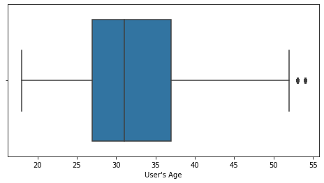

```python
plt.figure(figsize=(8,4))
sns.boxplot(data = df_copy, x = 'member_age')
plt.xlabel("User's Age");
```

**Observation:**

Age of users seems to have a right-tailed distribution, with the median age being around 31 years old.

The youngest users are aged 18 and the oldest being 54; the age floor may be due to requirements to sign up for the bike sharing program and the age ceiling from our data cleaning. We can also observe that the median age of the user is around 31 with the Q1 and Q3 of about 27 and 37 respectively.

Lets get a different look at the distribution density of age through a histogram.

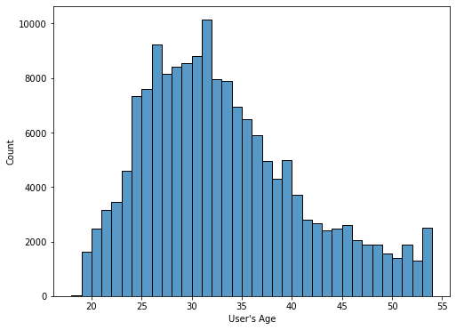

```python
# number of bins, to eaual the numbe of ages
bins = df_copy['member_age'].max() - df_copy['member_age'].min()

# plotting the histogram
plt.figure(figsize=(8,6))
sns.histplot(data = df_copy, x = 'member_age', bins=bins, color = blue)
plt.xlabel("User's Age");
```

**Observation:**

As expected from the previous box plot, the majority of users are between the 25 - 40 age range, with much fewer users above the age of 40, with the number of users lowering as age increases.

Next let's take a look at the day and time data available, specifically the start day and time of each ride. To do this we will extract the date and time data from the **start_time** feature

```python
# using datetime weekday to extract the day of the week; Monday denoted by 0 and ends on Sunday, denoted by 6
df_copy['day'] = df_copy['start_time'].dt.weekday
df_copy['day'].value_counts()
```

```
3    31635
1    28905
2    26794
4    25981
0    24056
6    13448
5    13398
Name: day, dtype: int64
```

With the day of the week extracted, we can now proceed plot the number of rides by the days of the week:

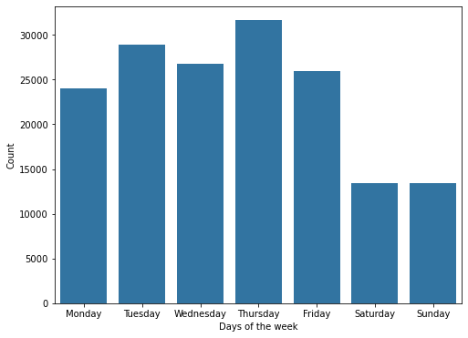

```python
# Assigning tick labels
days_of_the_week = ['Monday', 'Tuesday', 'Wednesday', 'Thursday', 'Friday', 'Saturday', 'Sunday']

# Plotting number of users by the days for the week
plt.figure(figsize=(8,6))
ax = sns.countplot(data= df_copy, x = 'day', color = blue)

ax.set_xticklabels(days_of_the_week)
plt.ylabel('Count')
plt.xlabel('Days of the week');
```

**Observation:**

The number of rides provides some intersting information. There are more rides on the weekdays than weekends; with Thursday having the most rides and Saturday having the least rides.

Next we will look at the start time of rides; to do this we will extract the ride start time from the **start_time** variable.

```python
# using datetime's hour to extract the start time hour
df_copy['start_hour'] = df_copy['start_time'].dt.hour
```

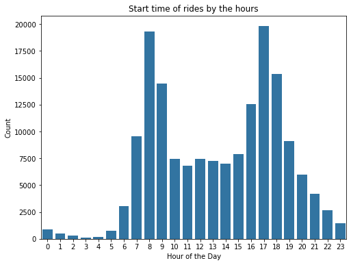

```python
# Plotting number of users by the days for the week
plt.figure(figsize=(8,6))
ax = sns.countplot(data= df_copy, x = 'start_hour', color = blue)

plt.title('Start time of rides by the hours')
plt.ylabel('Count')
plt.xlabel('Hour of the Day');
```

**Observation:**

The start time of rides also provides us with some distinct information. The start time of rides has a bimodal distribution, with peaks at 8am and 5pm. There are very few rides recorded between 11pm and 5am.

The morning and eveing peaks in rides, along with week days haviung more rides than weekends may suggest that many users may be using the bike sharing programme to commute to and fro from thier work/school commitments.

It might be interesting to explore how the distribution of ride start times, differs across the days of the week; specifically between weekdays and weekends.

```python
df_copy.head()
```

|  | duration_sec | start_time | end_time | start_station_id | start_station_name | start_station_latitude | start_station_longitude | end_station_id | end_station_name | end_station_latitude | end_station_longitude | bike_id | user_type | member_birth_year | member_gender | bike_share_for_all_trip | duration_min | member_age | day | start_hour |
| --- | --- | --- | --- | --- | --- | --- | --- | --- | --- | --- | --- | --- | --- | --- | --- | --- | --- | --- | --- | --- |
| 4 | 1585 | 2019-02-28 23:54:18.549 | 2019-03-01 00:20:44.074 | 7.0 | Frank H Ogawa Plaza | 37.804562 | -122.271738 | 222.0 | 10th Ave at E 15th St | 37.792714 | -122.248780 | 4898 | Subscriber | 1974 | Male | Yes | 26.416667 | 45 | 3 | 23 |
| 6 | 1147 | 2019-02-28 23:55:35.104 | 2019-03-01 00:14:42.588 | 300.0 | Palm St at Willow St | 37.317298 | -121.884995 | 312.0 | San Jose Diridon Station | 37.329732 | -121.901782 | 3803 | Subscriber | 1983 | Female | No | 19.116667 | 36 | 3 | 23 |
| 7 | 1615 | 2019-02-28 23:41:06.766 | 2019-03-01 00:08:02.756 | 10.0 | Washington St at Kearny St | 37.795393 | -122.404770 | 127.0 | Valencia St at 21st St | 37.756708 | -122.421025 | 6329 | Subscriber | 1989 | Male | No | 26.916667 | 30 | 3 | 23 |
| 8 | 1570 | 2019-02-28 23:41:48.790 | 2019-03-01 00:07:59.715 | 10.0 | Washington St at Kearny St | 37.795393 | -122.404770 | 127.0 | Valencia St at 21st St | 37.756708 | -122.421025 | 6548 | Subscriber | 1988 | Other | No | 26.166667 | 31 | 3 | 23 |
| 9 | 1049 | 2019-02-28 23:49:47.699 | 2019-03-01 00:07:17.025 | 19.0 | Post St at Kearny St | 37.788975 | -122.403452 | 121.0 | Mission Playground | 37.759210 | -122.421339 | 6488 | Subscriber | 1992 | Male | No | 17.483333 | 27 | 3 | 23 |

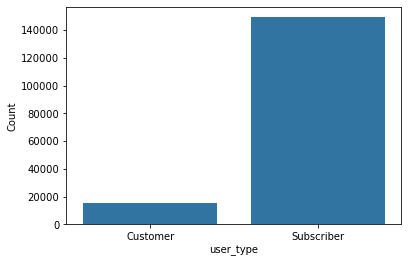

```python
# plotting number of customers vs subscribers
plt.figure(figsize=(6,4))
ax = sns.countplot(data= df_copy, x = 'user_type', color = blue)

plt.ylabel('Count');
```

**Observation:**

The most users are 'Subscribers' and 'Customers' making up a very small portion of the users.

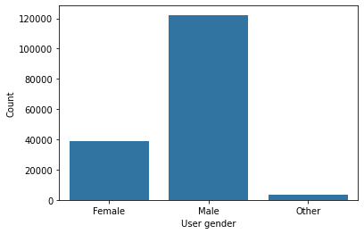

```python
# plotting users by gender
plt.figure(figsize=(6,4))
ax = sns.countplot(data= df_copy, x = 'member_gender', color = blue)

plt.ylabel('Count')
plt.xlabel('User gender');
```

**Observation:**

Most of the users are male, with around 3 times more male users than female users.

### What are some of the relationships observed in this part of the investigation?

The duration variable presented a wide range of values, with most of the values being short durations, with a right-tailed distribution. Under a log scale transformation, the duration variable took on a unimodal distribution with peaks around 7 to 12 minutes.

To get the day of the week and starting hour of each ride, the data had to be extracted from the 'start_time' feaure. From the plots, we discovered that weekdays had more rides than weekends, with Thursday having the most rides. Also, the starting hour of rides presented a bimodal distibution, with peaks at 8am and 5pm.

Most users are 'Subscribers' and 'Customers' making up a very small portion of the users and majority of the users are male with around 3 times more male than female users.

## 5. Bivariate Exploration

To kick-start our bivirate exploration, let's take a look ate the pairwise correlation between the features in the data; to see if antything interesting shows up.

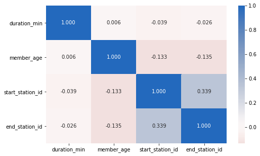

```python
# identifying interesting numeric variables.
numeric_vars = ['duration_min', 'member_age', 'start_station_id', 'end_station_id']

# plotting corelation heatmap
plt.figure(figsize = (8, 5))
sns.heatmap(df_copy[numeric_vars].corr(), annot = True, fmt = '.3f', cmap = 'vlag_r', center = 0)
plt.show()
```

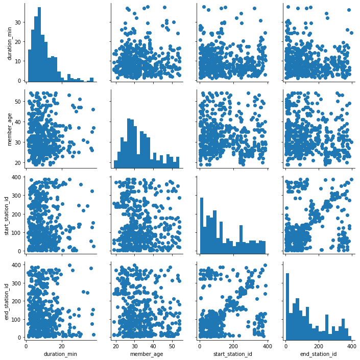

```python
# getting a random sample of 500 for clearer and faster plots
sample = df_copy.sample(500)

# plotting pairgrid w histogram diagonal & scatter plots
grid = sns.PairGrid(data = sample, vars = numeric_vars)
grid = grid.map_diag(plt.hist, bins = 20);
grid.map_offdiag(plt.scatter);
```

**Observation:**

Unsurprisingly, the 'start_station_id' and 'end_station_id' show a weak positive correlation. The other numeric features in the dataset do not seem the have any correlation. This is surprising as I expected 'members_age' and duration to have more of a correlation.

Let’s take a look deeper into ride duration and member's age. As the ride duration has a long right-tailed distribution, let us explore the if log-scaling the ride duration variable will provide any new insights into the realationship between ride duration and age.

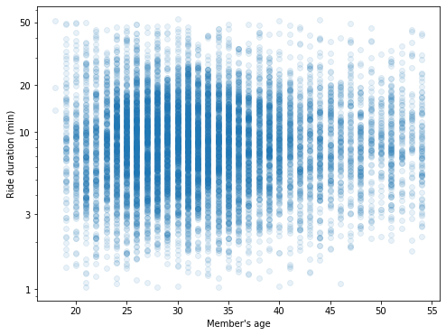

```python
# getting a random sample of 10000 for clearer and faster plots
sample = df_copy.sample(10000)

# Plotting the logscale
plt.figure(figsize=(8,6))
plt.scatter(data = sample, x = 'member_age', y = 'duration_min', alpha = 0.1)
plt.yscale('log');

plt.xlabel("Member's age")
plt.ylabel("Ride duration (min)")
plt.yticks([1,3,10,20,50], [1,3,10,20,50]);
```

It seems that even with the log-scale, although the plots are slightly clearer, it does not seem to provide much new insights into the relationship between members age and ride durations.

Next, let’s look into duration against some of the categorical variables.

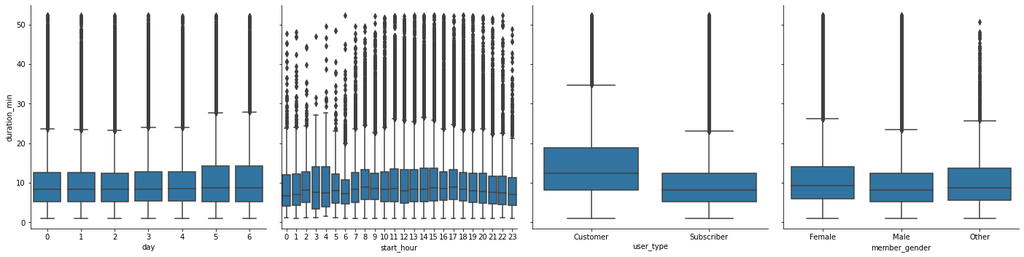

```python
boxplot_vars = ['day','start_hour', 'user_type', 'member_gender']

# plotting the PairGrid Boxplots
plt.figure(figsize = (15, 15));
grid = sns.PairGrid(data = df_copy, y_vars = ['duration_min'], x_vars = boxplot_vars, height = 5)
grid.map(sns.boxplot, color=blue);
```

**Observation:**

Next, lets take a closer look at ride duration across user types and gender.

[figure not shown]

```python
# Plotting duration by member_gender, subsetted by user_type
grid = sns.FacetGrid(data=df_copy, col = 'user_type', height = 8 )
grid.map(sns.boxplot, 'member_gender', 'duration_min')

grid.axes[0,0].set_xlabel('Ride start hour')
grid.axes[0,1].set_xlabel('Gender')
grid.axes[0,0].set_ylabel('Ride Duration (min)');
```

**Observation:**

In general, the findings are similar to our previous and does not really provide any new insight. Customers have longer ride duration than subscribers across all genders. For both customers and subscribers, females have higher median ride duration than males.

### What are some of the relationships observed in this part of the investigation?

Surprisingly, the age did not affect ride duration as much as expected going into this exploration. Time factors such as the hour of the day and day of the week seem to have an effect on ride durations, with hour of the day having more variability in ride durations. Most surprisingly, 'user_type' appears to have the most effect on ride durations, with 'customer' having longer ride durations than 'subscribers.

### Were any interesting relationships between the other features observed?

Unsurprisingly, a weak corelation was found between 'start_station_id' and 'end_station_id'. No other relationships were observed.

## 6. Multivariate Exploration

With what we have just explored, the main point of interest I would like to explore is how the 'user_type' affects ride duration across the other features of the dataset. Focusing on the categorical features of the dataset

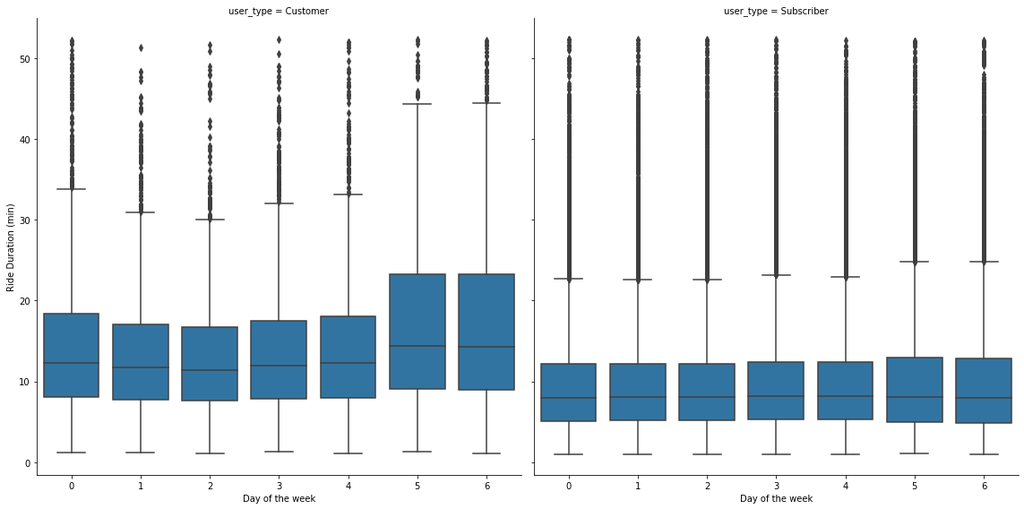

```python
# Plotting duration by day of the week, subsetted by user_type
grid = sns.FacetGrid(data=df_copy, col = 'user_type', height = 8)
grid.map(sns.boxplot, 'day', 'duration_min')

grid.axes[0,0].set_xlabel('Day of the week')
grid.axes[0,1].set_xlabel('Day of the week')
grid.axes[0,0].set_ylabel('Ride Duration (min)');
```

**Observation:**

As seen from before, overall, 'customer' users appear to have longer ride durations than 'subscriber' users. Interestingly, 'subscriber' users ride durations throughout the week appears very consistent, with similar median ride duration, of about 8 mins, and similar distributions across all 7 days of the week. Unlike 'subscriber' users, users categorised as 'customers' have varying median ride duration or around 12 mins across the weekdays, with a higher median ride duration on the weekends.

It appears that the user type does affect ride duration across the days of the week, with subscribers having shorter consistent ride durations across the week. This would suggest that the variability in the ride duration seen in the univariate exploration of ride distribution can be attributed to customers.

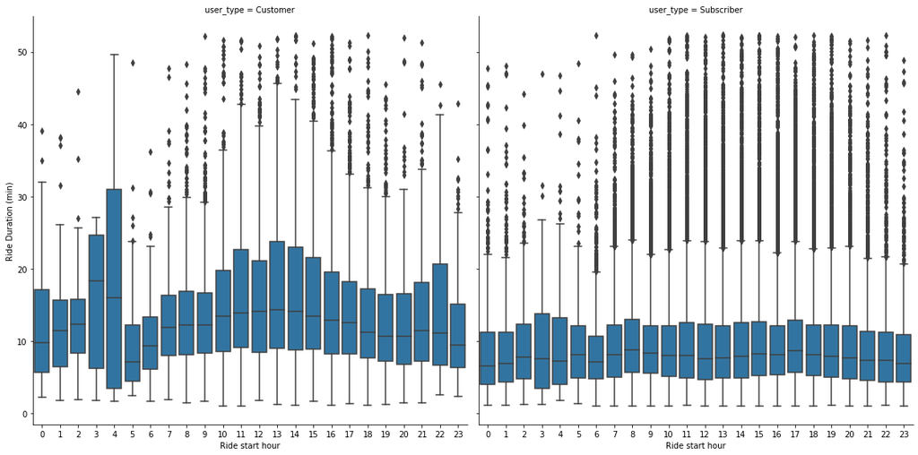

```python
# Plotting duration by hour of the day, subsetted by user_type
grid = sns.FacetGrid(data=df_copy, col = 'user_type', height = 8 )
grid.map(sns.boxplot, 'start_hour', 'duration_min')

grid.axes[0,0].set_xlabel('Ride start hour')
grid.axes[0,1].set_xlabel('Ride start hour')
grid.axes[0,0].set_ylabel('Ride Duration (min)');
```

The ride duration for subscribers, appears to share similarities to the PairGrid boxplot earlier in the notebook. This is unsurprising as subscribers make up majority of the users. However, it might be interesting to view the number of users by the hour alongside the above plot.

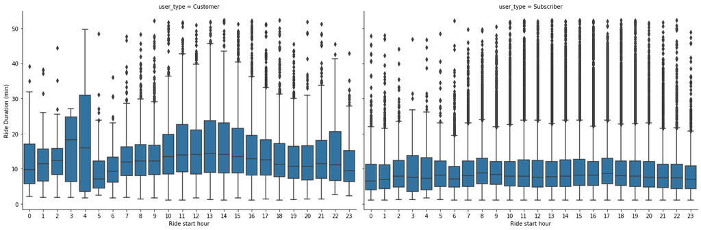

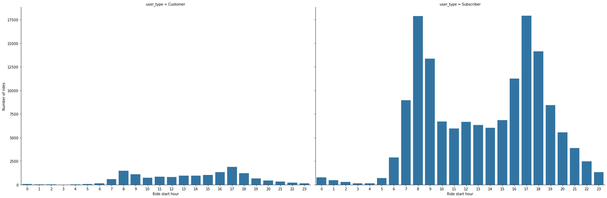

```python
# Plotting duration by hour of the day, subsetted by user_type
grid = sns.FacetGrid(data=df_copy, col = 'user_type', height = 6, aspect = 1.5 )
grid.map(sns.boxplot, 'start_hour', 'duration_min')

grid.axes[0,0].set_xlabel('Ride start hour')
grid.axes[0,1].set_xlabel('Ride start hour')
grid.axes[0,0].set_ylabel('Ride Duration (min)');

# plotting number of rides by hour of the day, subsetted by user_type
plt.figure(figsize=(5,10))
grid = sns.FacetGrid(data=df_copy, col = 'user_type', height = 8, aspect = 1.5 )
grid.map(sns.countplot, 'start_hour')

grid.axes[0,0].set_xlabel('Ride start hour')
grid.axes[0,1].set_xlabel('Ride start hour')
grid.axes[0,0].set_ylabel('Number of rides');
```

**Observation:**

For subscribers, ride duration appears to be very consistent, with similar median ride durations of around 7 mins across all the hours, despite the large difference in users across hours. However, it appears that the ride duration by the hour seems to share some similarities with the number or rides by the hour, both having peaks at 8am and 5pm.

For customers, there appears to have a average ride duration of 12 mins between 10am to 5pm with it peaking at 1pm. There is also noticeable variance in ride durations between midnight and 6am, but this may be due to the low number of rides from customers at these hours.

However, this raises the issue that maybe ride duration alone may not be a good way of interpreting bike usage on it's own.

Next, i would like to look at ride durations across both days of the week and hours of the day, for customers and subscribers. To do this, we will compare customer and subscribers hourly ride durations across each day of the week.

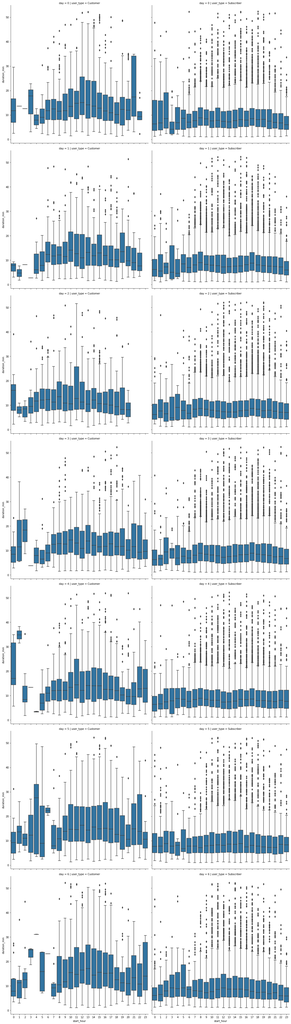

```python
plt.figure(figsize=(15,15))


grid = sns.FacetGrid(data = df_copy, col = 'user_type', row = 'day', height = 8)
grid.map(sns.boxplot, 'start_hour', 'duration_min');
```

**Observation:**

Overall, as we have already observed, customers have a higher ride duration compared to subscribers. Also, the variability in customer ride duration during non-peak hours become much more evident when comparing it across days, with a large amount of variability in ride duration distributions from 10pm till 8am.

For customers, the ride duration across the days do not seem to follow any specific distribution, with varying median ride duration and distributions across the days. Interestingly, customers are going on longer ride during the weekends as compared to rides on the weekday.

For subscribers, a more interesting observation can be made about the median ride duration between weekdays and weekends. On weekdays, the ride duration follows the distributions that we have observed thus far, with ride duration medians around 7 mins with peaks at around 8am and 5pm. However, on the weekend, the average median ride duration increases to around 9 mins, with peak median ride durations happening during 12 noon to 2pm.

These observations further emphasise how ride duration may not be the best matrics for to guage overall usage of the bikes.

To get a better visualisation of bike usage, I would like to explore the total duration of bike ride for each hour across both user types. To achieve this, we will add the sum of ride durations, grouped by their starting hour; for every hour of each day. This should give us a more complete picture of the usage of the bikes across each week.

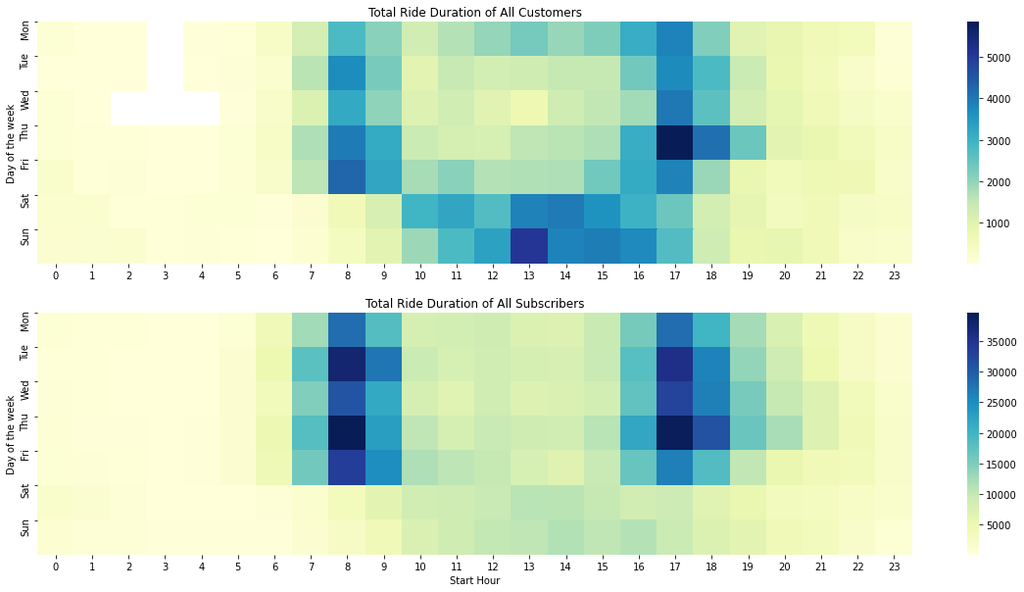

```python
plt.figure(figsize=(20,10))

plt.subplot(2,1,1)
hm_cust = df_copy.query('user_type == "Customer"').groupby(['day','start_hour'])['duration_min'].sum().reset_index()
hm_cust = hm_cust.pivot('day','start_hour','duration_min')
ax=sns.heatmap(hm_cust, cmap="YlGnBu")

plt.title('Total Ride Duration of All Customers')
plt.xlabel('')
plt.ylabel('Day of the week')
plt.yticks([0,1,2,3,4,5,6], ['Mon', 'Tue', 'Wed', 'Thu', 'Fri', 'Sat', 'Sun'])

plt.subplot(2,1,2)
hm_subs = df_copy.query('user_type == "Subscriber"').groupby(['day','start_hour'])['duration_min'].sum().reset_index()
hm_subs = hm_subs.pivot('day','start_hour','duration_min')
ax=sns.heatmap(hm_subs, cmap="YlGnBu")

plt.title('Total Ride Duration of All Subscribers')
plt.xlabel('Start Hour')
plt.ylabel('Day of the week')
plt.yticks([0,1,2,3,4,5,6], ['Mon', 'Tue', 'Wed', 'Thu', 'Fri', 'Sat', 'Sun']);
```

**Observation:** From the heatmaps above, the overall usage of bikes for both customers and subscribers becomes much clearer. From before, we know that customers generally take longer individual rides. However, due to the large number of subscribers over customers, the total usage of bikes is significantly higher for subscribers.

For subscribers on weekdays, it is clear that there are 2 peak periods of bike usage: 7am to 9am and 4pm to 7pm; with the highest usage happening at 8am and 5pm. Like their fellow user type, subscriber’s usage also changes during the weekends. Notably, subscribers bike usage is significantly less during weekends. For subscribers who do use the bikes on weekends, they tend to do so from 10am to 5pm.

### What are some of the relationships observed in this part of the investigation?

While exploring ride duration against the daily hours, it became clear that ride duration alone could not provide a full picture into the usage off the bikes. Although ride duration was able provided some insight into the difference in usage between customers, ultimately the large difference in the number of user types would play a large role when exploring the bike usage.

When we explored the total ride duration by all users across the hours of each day, the usage across the hours of the week became very clear. We were also able to observe a significant difference in overall bike usage patterns between weekdays and weekends.

```python
# saving the cleaned and edited dataset

df_copy.to_csv('bikedata_master.csv', index=False)
```